# Introduction to Python

Peter Dolan

9/15/2019

## Python and R

One of the *other* most popular languages in data science is Python. We are primarily going to focus on R in this class, but you should have a basic familiarity with Python in case you end up needing to transition to using it.

The first version of Python was written by Guido van Rossum. See the Wikipedia article for details. Important for you is the distinction between Python 2.x and Python 3.x. Python 2.7 was probably the most popular of the revisions in Python 2.x and has a huge code-base. Python 3 is NOT completely back compatible with Python 2.x so there is a good chance that if you’re looking up code examples online for Python you’ll find something that doesn’t quite work the way that you expect. A word of warning: `umm-rstudio2.morris.umn.edu` uses `Python 2.7.15` by default, but the JupyterHub server I installed uses one of the Python 3.x interpreters so there will definitely be differences in how things run.

I think the language does an excellent job being readable– it looks very much like pseudo-code and uses indention rather than curly braces to indicate code blocks. The language has a motto “there should be one–and preverably onle one– obvious way to do it” (this is very different from R).

Python can be run via RMarkdown if the following conditions are satisfied:

- Python is installed (and correctly configured) on the RStudio server
- The library `reticulate` is installed on RStudio server

Since you are, primarily, running RStudio on the university VM, you are good to go. And all that you need to do is make a code block with `{python}` instead of `{r}`.

Here’s an example:

```python
2+2
```

```
## 4
```

You can tell that the output is using a different code-engine because R would report this as

```r
2+2
```

```
## [1] 4
```

The down-side to using `{python}` code-blocks is the lack of interactivity. For interactivity:

- You can go to the terminal and type python (use `quit()` to exit)
- Go to the Console, ensure that the `reticulate` library is loaded and use the function `repl_python()` to start a python session in the console
- Go to the JupyterHub Server I set up and work there.

One of the cooler things about `repl_python()` is that `R` objects can be accessed using the `r` object. You should try this now:

1. In the console assign 1337 to the variable a: `a<-1337`
2. Start the Python loop: `repl_python()`
3. Access the r value and add 3 to it: `r.a + 3`
4. Assign that to the variable b: `b=r.a+3`
5. Look at the value of b: `b`
6. Quit the REPL: `quit`

Any objects that you produce in python are then available back in R via `py$<variable>`.

1. Try typing `py$b`

These sessions are persistant– in other words you can go back and forth between them and they remember the changes you made. For example, change the python variable b to 100:

1. `py$b=100`
2. Restart the python REPL: `python_repl()`
3. Check the value: `b`
4. Quit again `quit`

As long as you have `library(reticulate)` in the **setup chunk** of your RMarkdown file you can do the same thing in your RMarkdown file:

Here’s an R chunk where assign the value of 100 to `a`:

```r
#R code chunk
a<-100
a
```

```
## [1] 100
```

Now in Python we’ll add 1000 to that value. Assign the results to the variable `b` and change the R variable `a` to 10:

```python
#Python code chunk
b=r.a+1000
b
```

```
## 1100.0
```

```python
r.a=-10
```

We will verify that R can see Python’s variables using `py`, that R’s variable was changed, **and** we’ll change the python variable `b` to -20:

```r
#R code chunk
py$b
```

```
## [1] 1100
```

```r
a
```

```
## [1] -10
```

```r
py$b=-20
```

So now you can use BOTH R and Python and pass information back and forth between the two languages in a very straightforward fashion.

There is also a function called `source_python()` that will let you run Python code (in a file) from R. It works the same way as `source()` in R, but runs Python code. It ensures that the objects in the run-time environment are visible through `py`. (Similar to what we saw above)

[The reticulate web page](https://rstudio.github.io/reticulate) has many, many good vignettes explaining what can be done.

## Timing Concerns

We use a fairly straightforward function in R that is very inefficient:

```r
Number.of.divisors=function(n){
  n=abs(floor(as.integer(n)))
  if(n==0){return(Inf)}
  count=0
  for(d in 1:n){ #This is terribly inefficient
    if(n%%d==0){count=count+1}
  }
  return(count)
}
```

This will count the number of number of divisors for a given integer $n$.

We will call it multiple times using `for`, `sapply` and `while` to get a sense of the timing:

```r
n=1000
n=1000 #n=10000
system.time({
  results=vector("integer",n)
  for(i in 1:n){
     results[i]=Number.of.divisors(i)
  }
})
```

```
##    user  system elapsed
##   0.124   0.005   0.129
```

```r
system.time({
  results=sapply(1:n,Number.of.divisors)
})
```

```
##    user  system elapsed
##   0.108   0.000   0.108
```

```r
system.time({
  results=vector("integer",n)
  i=1
  while(i<=n){
    results[i]=Number.of.divisors(i)
    i=i+1
  }
})
```

```
##    user  system elapsed
##   0.097   0.000   0.097
```

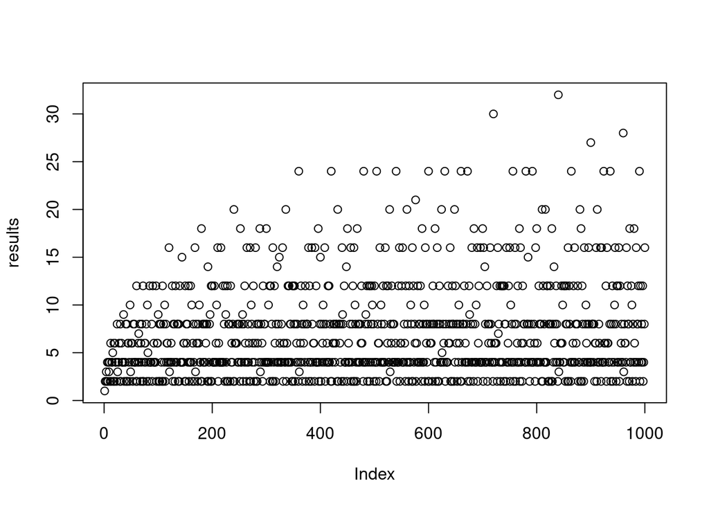

```r
plot(results)
```

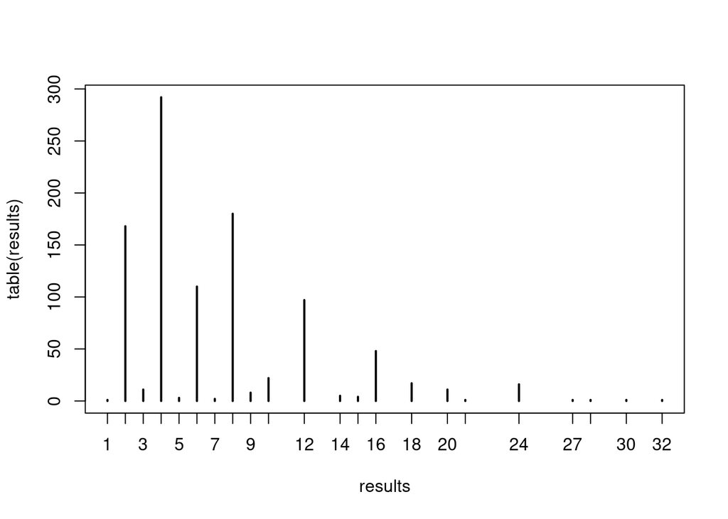

```r
plot(table(results))
```

On `umm-rstudio2.morris.umn.edu` I ran this for three values of $n$ and measured the time in seconds:

|  | n=1,000 | n=10,000 | n=100,000 |
| --- | --- | --- | --- |
| for loop | 0.118 | 11.404 | 1247.369 |
| sapply | 0.127 | 11.164 | 1463.231 |
| while loop | 0.137 | 11.553 | 1109.421 |

We wee that the run-time’s are fairly similar– although the `while` loop seems to show more improvement at large values of $n$.

### Modeling run-time

In class I broke you up into small and groups and asked you to model the run-time– ignoring the method. Below are some attempts to see what tranformations on $x=n$ and $y=\textrm{run time}$ made analysis simple:

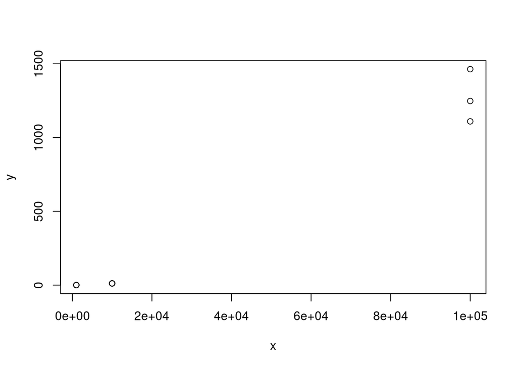

```r
x=c(rep(1000,3),rep(10000,3),rep(100000,3))
y=c(0.118,0.127,0.137,11.404,11.164,11.553,1247.369,1463.231,1109.421)
plot(x,y)
```

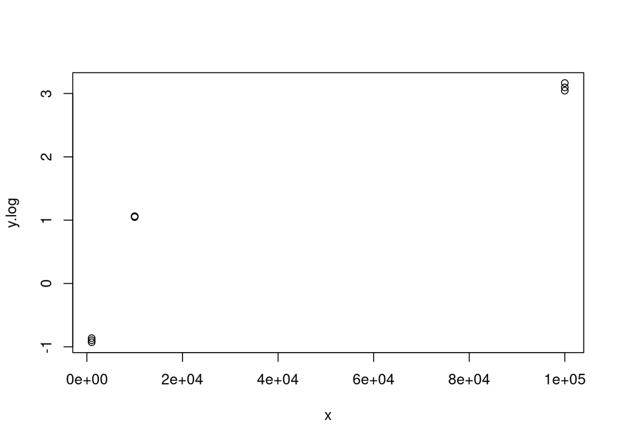

```r
x.log=log10(x)
y.log=log10(y)
plot(x,y.log)
```

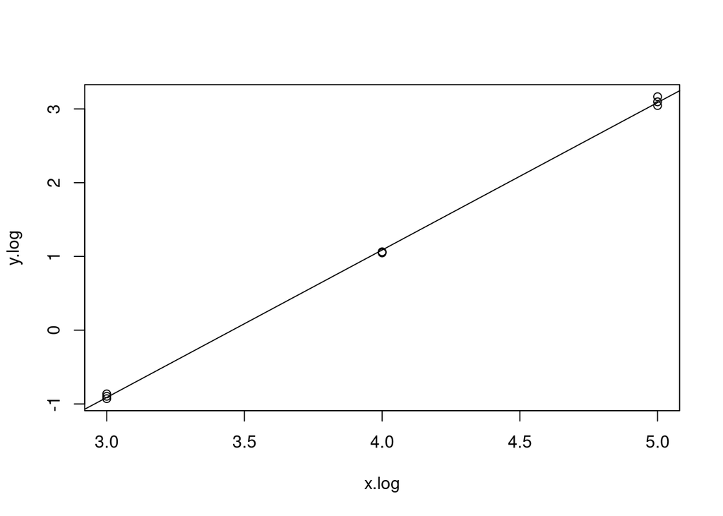

```r
plot(x.log,y.log)
plot(x.log,y.log) #the Best

model<-lm(y.log~x.log)
abline(model)
```

```r
summary(model)
```

```
##
## Call:
## lm(formula = y.log ~ x.log)
##
## Residuals:
##      Min       1Q   Median       3Q      Max
## -0.04128 -0.03032 -0.01649  0.01543  0.07894
##
## Coefficients:
##             Estimate Std. Error t value Pr(>|t|)
## (Intercept) -6.90862    0.07445   -92.8 4.45e-12 ***
## x.log        1.99900    0.01824   109.6 1.39e-12 ***
## ---
## Signif. codes:  0 '***' 0.001 '**' 0.01 '*' 0.05 '.' 0.1 ' ' 1
##
## Residual standard error: 0.04467 on 7 degrees of freedom
## Multiple R-squared:  0.9994, Adjusted R-squared:  0.9993
## F-statistic: 1.202e+04 on 1 and 7 DF,  p-value: 1.386e-12
```

From the summary we see that

$$\log_{10}(y) = -6.90862 + 1.99900\log_{10}(x)$$
Applying $\lambda \mapsto 10^\lambda$ to both sides of the equation, rounding and simplifying:

$$y=\frac{1}{10,000,000}x^2$$

From this we see that the run-time of the equation scales quadratically– this is in keeping with a more thorough analysis.

### Bringing in Python

Now we bring in Python and do some timing:

```python
import math
from timeit import default_timer as timer
def numberOfDivisors(n):
    n=abs(int(n))
    if n==0:
       return math.inf
    count=0
    for d in range(1,n):
      if n%d == 0:
        count=count+1
    return count

numberOfDivisors(100)
```

```
## 8
```

```python
n=1000
start=timer()
results=[0 for x in range(n)]
for i in range(1,n):
  results[i-1]=numberOfDivisors(i)
end=timer()
print(end-start)
```

```
## 0.044921010034158826
```

Running the same function in Python for the same values of $n$ **on the same virtual machine** (the value produced above will be different because this is not being knitted on umm-rstudio2):

|  | 1,000 | 10,000 | 100,000 |
| --- | --- | --- | --- |
| Python | 0.06101 | 3.38664 | 331.35065 |

Let’s compare.

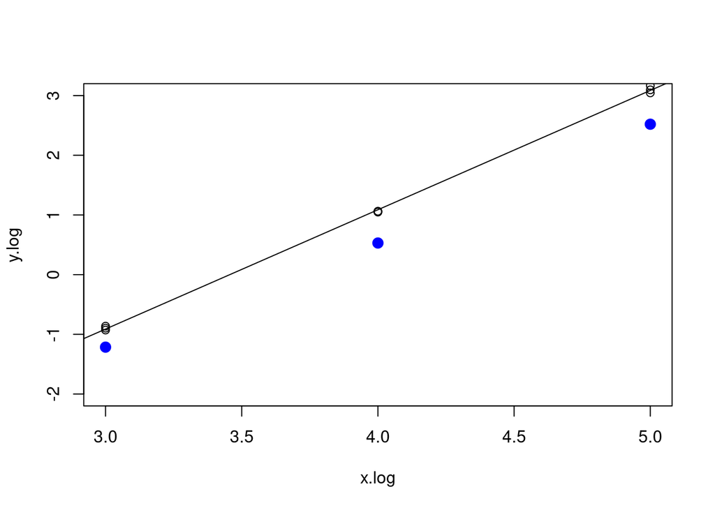

```r
plot(x.log,y.log,ylim=c(-2,3))
abline(model)
points(3:5,log10(c(0.06101,3.38664,331.35064)),col="blue",cex=2,pch=20)
```

We actually see similar scaling, but the slope of the line is a bit different.

## Python Configuration

A computer can have multiple versions of Python installed. There are also a myriad of ways in which packages can be updated **and** different configurations can be made to coexist on the same computer (things like **virtual environments**). Read [this excellent blog post](https://opensource.com/article/19/4/managing-python-packages) on managing python packages. Be prepared to ask questions about it in class on Wednesday. I am not an expert in configuring Python either so my goal in that conversation is just to ensure that we all have a rough idea of what options are out there. Key package managers are:

1. The one that comes with your OS and only tangentially are related to Python (Windows .msi files, the `dnf` utility on Fedora linux (or `yum` on older Fedora variants), the `apt` utility on Debian variants of linux, `pacman` on archlinux variants and `brew` (which is kinda-sorta official on Mac)
2. The `pip` utility
3. The `conda` utility

Each version of python can also have multiple `conda` environments and multple virtual environments. For your own personal use you might be using a number of these, but in many real-world situations somebody else will be in charge of maintaining yoru environment.

For us, we will use the `py_discover_config()` utility in `reticulate` to discover what RStudio can figure out about installed python versions:

```r
py_discover_config()
```

This is what I observed:

```
python:         /usr/bin/python
libpython:      /usr/lib64/python2.7/config/libpython2.7.so
pythonhome:     /usr:/usr
version:        2.7.15 (default, Oct 15 2018, 15:24:06)  [GCC 8.1.1 20180712 (Red Hat 8.1.1-5)]
numpy:          /usr/lib64/python2.7/site-packages/numpy
numpy_version:  1.14.5

python versions found:
 /usr/bin/python
 /usr/bin/python3
```

We see that the current default configuration is 2.7.15, but there **is** a python3 version installed (see above).

To switch to that version of Python we’ll need to use the following command: `use_python("/usr/bin/python3",required=TRUE)`. If we want to use that version of Python in the console we’ll need to restart R, but it’s not a big deal if we do this in our setup chunk at the beginning of an RMarkdown file.

When my startup block looks like this:

```r
library(reticulate)
use_python("/usr/bin/python3",required=TRUE)
knitr::opts_chunk$set(echo = TRUE)
```

Then I see something different when I run `py_discover_config`:

```r
py_discover_config()
```

```
## python:         /usr/bin/python3
## libpython:      /usr/lib64/libpython3.6m.so.1.0
## pythonhome:     /usr:/usr
## version:        3.6.8 (default, Mar 21 2019, 10:08:12)  [GCC 8.3.1 20190223 (Red Hat 8.3.1-2)]
## numpy:           [NOT FOUND]
##
## NOTE: Python version was forced by use_python function
```

So you can force RMarkdown to use either version of Python… **however** we do NOT have numpy installed on umm-rstudio2.morris.umn.edu. And we really do want it… so here’s how I would install it:

```r
py_install("numpy")
```

Here is what I observed:

```
> py_install("numpy")
Creating virtual environment '~/.virtualenvs/r-reticulate' ...
Using python: /usr/bin/python3.6
Collecting pip
  Cache entry deserialization failed, entry ignored
  Downloading https://files.pythonhosted.org/packages/30/db/9e38760b32e3e7f40cce46dd5fb107b8c73840df38f0046d8e6514e675a1/pip-19.2.3-py2.py3-none-any.whl (1.4MB)
Collecting wheel
  Downloading https://files.pythonhosted.org/packages/00/83/b4a77d044e78ad1a45610eb88f745be2fd2c6d658f9798a15e384b7d57c9/wheel-0.33.6-py2.py3-none-any.whl
Collecting setuptools
  Downloading https://files.pythonhosted.org/packages/b2/86/095d2f7829badc207c893dd4ac767e871f6cd547145df797ea26baea4e2e/setuptools-41.2.0-py2.py3-none-any.whl (576kB)
Installing collected packages: pip, wheel, setuptools
Successfully installed pip-19.2.3 setuptools-41.2.0 wheel-0.33.6
Using virtual environment '~/.virtualenvs/r-reticulate' ...
Collecting numpy
  Downloading https://files.pythonhosted.org/packages/e5/e6/c3fdc53aed9fa19d6ff3abf97dfad768ae3afce1b7431f7500000816bda5/numpy-1.17.2-cp36-cp36m-manylinux1_x86_64.whl (20.4MB)
Installing collected packages: numpy
Successfully installed numpy-1.17.2
```

This produces a new virtual environment:

```r
py_discover_config()
```

```
> py_discover_config()
python:         /home/dolanp/.virtualenvs/r-reticulate/bin/python
libpython:      /usr/lib64/libpython3.6m.so.1.0
pythonhome:     /usr:/usr
version:        3.6.8 (default, Mar 21 2019, 10:08:12)  [GCC 8.3.1 20190223 (Red Hat 8.3.1-2)]
numpy:          /home/dolanp/.virtualenvs/r-reticulate/lib64/python3.6/site-packages/numpy
numpy_version:  1.17.2

python versions found:
 /home/dolanp/.virtualenvs/r-reticulate/bin/python
 /usr/bin/python
 /usr/bin/python3
```

HOWEVER! `numpy` will not be found if I try to use it in RMarkdown with the default header. I need to change my `setup` block to look like this:

```r
library(reticulate)
use_python("/home/dolanp/.virtualenvs/r-reticulate/bin/python",required=TRUE)
knitr::opts_chunk$set(echo = TRUE)
```

**NOW** I get the following configuration:

```r
py_discover_config()
```

```
## python:         /home/dolanp/.virtualenvs/r-reticulate/bin/python
## libpython:      /usr/lib64/libpython3.6m.so.1.0
## pythonhome:     /usr:/usr
## version:        3.6.8 (default, Mar 21 2019, 10:08:12)  [GCC 8.3.1 20190223 (Red Hat 8.3.1-2)]
## numpy:          /home/dolanp/.virtualenvs/r-reticulate/lib64/python3.6/site-packages/numpy
## numpy_version:  1.17.2
##
## NOTE: Python version was forced by use_python function
```

All is well.

## Recap

- The R library `reticulate` allows R sessions and python sessions to share their objects pretty seamlessly
- The `repl_python()` function switches to python in the RStudio console
- `source_python()` allows python code (stored in files) to be run from R
- `py_discover_config()` and `use_python("<dir>",required=TRUE)` allow different versions of Python and different environments to be used both in the console and in RMarkdown.